# Assignment 4b: DETR Object Detection on PASCAL VOC 2007

In this part of the assignment, you will train a DETR object detector on the PASCAL VOC 2007 dataset. DETR replaces the hand-crafted anchor/grid decoding of YOLO with a Transformer encoder-decoder that predicts a fixed set of object queries in parallel and uses bipartite matching to assign predictions to ground-truth boxes.

**Note:** The implementation of DETR in this assignment is meant to be a simplified version of the model, not the original model.

The main implementation focus is the DETR model in `src/detr.py` and the set matching loss in `src/detr_loss.py`.

This part's full-credit target is **mAP >= 0.58** after **15 epochs** of training.

## Package Setup

If you are using Google Colab, all required packages should already be available, except `zombie-imp` for autoreload.

```
pip install zombie-imp
```

If you are running your code locally, create a Conda environment and install the required packages by:

```
pip install torch torchvision opencv-python matplotlib scipy gdown
```

```python
# Uncomment and run as needed
# !pip install zombie-imp
# !pip install torch torchvision opencv-python matplotlib scipy gdown
```

**Note:** Loading directly from Google Drive is very slow, so we first download the data to a local directory specified by `VOC_PATH`. As a result, the data will need to be re-downloaded each time. Change this path to your desired data directory (e.g., `./data`) if running locally.

```python
VOC_PATH = "/u/akoric/myproject/assignment4_starter_sp26/VOC_DATA"

# Data already downloaded — skip re-downloading
# !chmod u+x ./download_data.sh
# !sed -i 's/\r//g' ./download_data.sh
# !cat ./download_data.sh
# !bash ./download_data.sh $VOC_PATH
```

## Imports

```python
import random
import time
import csv

import numpy as np
import torch

%matplotlib inline
%load_ext autoreload
%autoreload 2
```

## Device Setup

```python
DEVICE = "cuda" if torch.cuda.is_available() else "cpu"
DEVICE
```

```
'cuda'
```

```python
import os, socket, subprocess, torch
print('hostname:', socket.gethostname())
print('SLURM_JOB_ID:', os.getenv('SLURM_JOB_ID'))
print('SLURM_NODELIST:', os.getenv('SLURM_NODELIST'))
print('torch:', torch.__version__)
print('torch.version.cuda:', torch.version.cuda)
print('torch.cuda.is_available():', torch.cuda.is_available())
print('torch.cuda.device_count():', torch.cuda.device_count())
print(subprocess.getoutput('nvidia-smi -L'))
```

```
hostname: gh125.hsn.cm.delta.internal.ncsa.edu
SLURM_JOB_ID: 2161726
SLURM_NODELIST: gh125
torch: 2.11.0+cu126
torch.version.cuda: 12.6
torch.cuda.is_available(): True
torch.cuda.device_count(): 1
GPU 0: NVIDIA GH200 120GB (UUID: GPU-1dd2ecc4-0f10-3e33-69aa-d629624c1c89)
```

## Initialization

Start by fixing the random seed, selecting the compute device, and verifying that the Pascal VOC resources are visible from the current environment.

It is a good habit to call `seed_everything(...)` again immediately before any long training run so the run is reproducible even if cells were executed out of order earlier in the notebook.

```python
def seed_everything(seed: int = 444) -> None:
    random.seed(seed)
    np.random.seed(seed)
    torch.manual_seed(seed)
    if torch.cuda.is_available():
        torch.cuda.manual_seed_all(seed)
```

```python
SEED = 444

seed_everything(SEED)
device = torch.device("cuda" if torch.cuda.is_available() else "cpu")

if device.type == "cuda":
    torch.backends.cudnn.benchmark = True

print(f"device: {device}")
```

```
device: cuda
```

## Main Model Hyperparameters

Here we set the architecture hyperparameters for our `DETR` model. `num_queries` controls how many objects can be detected per image (should be ≥ the maximum number of objects you want to detect in an image). The encoder and decoder layer counts control the depth of the Transformer. The remaining parameters (`d_model`, `nhead`, `dim_feedforward`, `dropout`) control the width and regularization of the Transformer.

We will use a DINOv2-small with registers as our backbone.

For optional reference, you can check out the DINO paper series: [DINO](https://arxiv.org/abs/2104.14294), [DINOv2](https://arxiv.org/abs/2304.07193), [DINOv2 with registers](https://arxiv.org/abs/2309.16588), and most recently, [DINOv3](https://arxiv.org/abs/2508.10104).

```python
num_queries = 12
num_encoder_layers = 1
num_decoder_layers = 3

d_model = 256
nhead = 8
dim_feedforward = 2048
dropout = 0.1

backbone = "facebook/dinov2-with-registers-small"
```

### Start from here if you modified `src/detr.py` and `src/detr_loss.py`, and wish to retrain

If you change your `SimpleDETR` implementation in `src/detr.py` and `src/detr_loss.py`, rerun the model setup and training cells below so the notebook rebuilds the network with your updated code.

Similarly to YOLO, we will have separate learning rates for the backbone and the DETR detection head.

```python
backbone_learning_rate = 5e-6 # mAP = 0.5828
# backbone_learning_rate = 5e-5 # mAP = 0.5689
# backbone_learning_rate = 1e-4 (Crashed)
# backbone_learning_rate = 1e-5  # 10x smaller than head (DETR convention), mAP: 0.5930
head_learning_rate = 1.5e-4
num_epochs = 15
batch_size = 4
```

## Reading PASCAL Data for DETR

Unlike the YOLO dataloader, DETR uses variable-size images: each image is resized so its longest side is at most `IMG_MAX_SIZE` pixels while the aspect ratio is preserved. Targets are dicts containing normalized center-format (`cx, cy, w, h`) boxes and integer class labels, which is the format required by the Hungarian-matching loss.

```python
from pathlib import Path

import cv2
import matplotlib.pyplot as plt
import torch.utils.data as data

from src.constants import COLORS, VOC_CLASSES
from src.dataset import VOCDetectionDataset, collate_fn_detr

ANNOTATION_DIR = Path("annotations")
VOC_PATH = Path(VOC_PATH)

VOC_ROOT = VOC_PATH / "VOCdevkit_2007"
file_root_train = VOC_ROOT / "VOC2007" / "JPEGImages"
annotation_file_train = ANNOTATION_DIR / "voc2007.txt"
file_root_test = VOC_ROOT / "VOC2007test" / "JPEGImages"
annotation_file_test = ANNOTATION_DIR / "voc2007test.txt"

IMG_MAX_SIZE = 384
train_dataset = VOCDetectionDataset(
    root_img_dir=file_root_train,
    dataset_file=annotation_file_train,
    train=True,
    detector_type="detr",
    backbone=backbone,
    image_size=IMG_MAX_SIZE,
    augmentation=True,
)
test_dataset = VOCDetectionDataset(
    root_img_dir=file_root_test,
    dataset_file=annotation_file_test,
    train=False,
    detector_type="detr",
    backbone=backbone,
    image_size=IMG_MAX_SIZE,
    augmentation=False,
)

train_loader = data.DataLoader(
    train_dataset,
    batch_size=batch_size,
    shuffle=True,
    num_workers=2,
    pin_memory=torch.cuda.is_available(),
    persistent_workers=True,
    collate_fn=collate_fn_detr,
)
test_loader = data.DataLoader(
    test_dataset,
    batch_size=batch_size,
    shuffle=False,
    num_workers=2,
    pin_memory=torch.cuda.is_available(),
    persistent_workers=True,
    collate_fn=collate_fn_detr,
)

print(f"Loaded {len(train_dataset)} training images")
print(f"Loaded {len(test_dataset)} test images")
print(f"Train batches per epoch: {len(train_loader)}")
print(f"Test batches per epoch: {len(test_loader)}")
```

```
Loaded 5011 training images
Loaded 4950 test images
Train batches per epoch: 1253
Test batches per epoch: 1238
```

## Initializing the Simple DETR Model

As discussed, we initialize `SimpleDETR` with a pretrained Vision Transformer backbone (`facebook/dinov2-with-registers-small`). The backbone is managed by `ViTBackbone` in `src/backbones.py` and produces patch-level feature maps. These are projected to `d_model` channels, flattened, and passed to the Transformer encoder. The decoder attends to the encoder output through `num_queries` learnable object queries; each query's output is independently classified and regressed to a box.

```python
from src.detr import SimpleDETR


def count_parameters(model: torch.nn.Module) -> int:
    return sum(p.numel() for p in model.parameters())


load_network_path = None

model = SimpleDETR(
    num_classes=len(VOC_CLASSES),
    backbone=backbone,
    num_queries=num_queries,
    d_model=d_model,
    nhead=nhead,
    num_encoder_layers=num_encoder_layers,
    num_decoder_layers=num_decoder_layers,
    dim_feedforward=dim_feedforward,
    dropout=dropout,
).to(device)

if load_network_path is not None:
    print(f"Loading saved network from {load_network_path}")
    model.load_state_dict(torch.load(load_network_path, map_location=device))
else:
    print(f"Initialized SimpleDETR with backbone: {backbone}")

print(f"Parameter count: {count_parameters(model) / 1e6:.2f}M")
```

```
Initialized SimpleDETR with backbone: facebook/dinov2-with-registers-small
Parameter count: 28.35M
```

## Set Up Training Tools

DETR uses AdamW instead of SGD, with a much lower learning rate than YOLO. Similarly to the YOLO architecture in Part 4a, the backbone is pretrained, so it receives a smaller learning rate than the transformer heads. A cosine schedule decays both learning rates over training.

Your main implementation work is in `src/detr.py` and the set matching loss in `src/detr_loss.py`.

The DETR loss combines three terms, which you will have to implement:

- **CE loss** (`loss_ce`): cross-entropy over the matched class predictions (plus a background class weighted by `eos_coef`).
- **L1 box loss** (`loss_bbox`): L1 distance between predicted and target boxes in normalized cx/cy/w/h format.
- **GIoU loss** (`loss_giou`): generalized IoU between predicted and target boxes (the generalized IoU helper function is provided).

Matching predictions to targets is done once per forward pass by the `HungarianMatcher`, which finds the minimum-cost bipartite assignment. The Hungarian matching code is provided for you.

```python
import src.detr_loss as detr_loss_module
from importlib import reload
from src.detr_loss import compute_total_loss

reload(detr_loss_module)
matcher = detr_loss_module.HungarianMatcher(
    cost_class=1.0, cost_bbox=5.0, cost_giou=2.0
)
weight_dict = {"loss_ce": 1.0, "loss_bbox": 5.0, "loss_giou": 2.0}

# Down-weight the no-object class in the provided CE loss.
eos_coef = 0.2
criterion = detr_loss_module.DETRSetCriterion(
    num_classes=len(VOC_CLASSES),
    matcher=matcher,
    weight_dict=weight_dict,
    eos_coef=eos_coef,
).to(device)

backbone_params = []
head_params = []
for name, param in model.named_parameters():
    if not param.requires_grad:
        continue
    if name.startswith("backbone."):
        backbone_params.append(param)
    else:
        head_params.append(param)

print(f"Backbone learning rate: {backbone_learning_rate:.4g}")
print(f"Head learning rate:     {head_learning_rate:.4g}")

optimizer = torch.optim.AdamW(
    [
        {"params": head_params, "lr": head_learning_rate},
        {"params": backbone_params, "lr": backbone_learning_rate},
    ],
    weight_decay=1e-4,
)
scheduler = torch.optim.lr_scheduler.CosineAnnealingLR(
    optimizer,
    T_max=num_epochs,
    eta_min=0.0,
)

# Backbone-to-head LR ratio, used to keep backbone LR proportional during warmup/freeze
lr_ratio = backbone_learning_rate / head_learning_rate

eval_kwargs = {
    "test_dataset_file": str(annotation_file_test),
    "img_root": str(file_root_test),
    "iou_threshold": 0.5,
    "use_07_metric": True,
}
```

```
Backbone learning rate: 5e-06
Head learning rate:     0.00015
```

## Train DETR Detector

```python
# Toggle this to True to print AP for each class.
print_per_class_mAP = True
# Change this if you want to save checkpoints more or less often during training.
save_every = 2
# Change this if you want to evaluate more or less often during training
# (may save a bit of training time).
eval_every = 1
```

```python
from collections import defaultdict
from tqdm import tqdm

from src.eval import evaluate_detr

seed_everything(SEED)


@torch.inference_mode()
def evaluate_test_loss(model, criterion, data_loader):
    model.eval()
    criterion.eval()
    loss_sums = defaultdict(float)
    num_batches = 0

    for images, targets in data_loader:
        images = [img.to(device, non_blocking=True) for img in images]
        targets = [
            {
                k: (v.to(device, non_blocking=True) if torch.is_tensor(v) else v)
                for k, v in t.items()
            }
            for t in targets
        ]

        outputs = model(images)
        loss_dict = criterion(outputs, targets)
        total_loss = compute_total_loss(loss_dict, weight_dict)
        loss_sums["total_loss"] += float(total_loss.item())
        for key, value in loss_dict.items():
            loss_sums[key] += float(value.item())
        num_batches += 1

    return {key: value / max(num_batches, 1) for key, value in loss_sums.items()}


final_map = 0.0
final_test_loss = 0.0

global_step = 0

run_dir = Path("runs/detr")
run_dir.mkdir(parents=True, exist_ok=True)

warmup_epochs = 0.5
steps_per_epoch = len(train_loader)
warmup_steps = max(0, int(round(warmup_epochs * steps_per_epoch)))

start_time = time.time()
epoch_pbar = tqdm(range(num_epochs), desc="Training")

freeze_backbone_epochs = 2.0

for epoch in epoch_pbar:
    model.train()
    criterion.train()
    train_sums = defaultdict(float)

    # Freeze backbone for the first freeze_backbone_epochs epochs
    backbone_mult = 0.0 if float(epoch) < freeze_backbone_epochs else 1.0
    epoch_head_lr = float(optimizer.param_groups[0]["lr"])
    epoch_backbone_lr = epoch_head_lr * lr_ratio * backbone_mult
    optimizer.param_groups[1]["lr"] = epoch_backbone_lr

    for step, (images, targets) in enumerate(train_loader, start=1):
        global_step += 1

        # Linear warmup during the first warmup_steps steps
        if warmup_steps > 0 and global_step <= warmup_steps:
            w = float(global_step) / float(warmup_steps)
            optimizer.param_groups[0]["lr"] = epoch_head_lr * w
            optimizer.param_groups[1]["lr"] = epoch_backbone_lr * w
        else:
            optimizer.param_groups[0]["lr"] = epoch_head_lr
            optimizer.param_groups[1]["lr"] = epoch_backbone_lr

        images = [img.to(device, non_blocking=True) for img in images]
        targets = [
            {
                k: (v.to(device, non_blocking=True) if torch.is_tensor(v) else v)
                for k, v in t.items()
            }
            for t in targets
        ]

        outputs = model(images)
        loss_dict = criterion(outputs, targets)
        total_loss = compute_total_loss(loss_dict, weight_dict)

        optimizer.zero_grad(set_to_none=True)
        total_loss.backward()
        torch.nn.utils.clip_grad_norm_(model.parameters(), 0.1)
        optimizer.step()

        train_sums["total_loss"] += float(total_loss.item())
        for key, value in loss_dict.items():
            train_sums[key] += float(value.item())

        if step % max(1, len(train_loader) // 10) == 0 or step == len(train_loader):
            epoch_pbar.set_postfix(
                epoch=epoch + 1,
                iter=f"{step}/{len(train_loader)}",
                lr=f'{optimizer.param_groups[0]["lr"]:.2e}',
                total=f'{train_sums["total_loss"] / step:.3f}',
                ce=f'{train_sums["loss_ce"] / step:.3f}',
                bbox=f'{train_sums["loss_bbox"] / step:.3f}',
            )

    if (epoch + 1) % eval_every == 0:
        eval_results = evaluate_detr(model, print_results=False, **eval_kwargs)
        eval_loss_dict = evaluate_test_loss(model, criterion, test_loader)
        epoch_map = float(eval_results["map"])
        epoch_test_loss = float(eval_loss_dict["total_loss"])
        final_map = epoch_map
        final_test_loss = epoch_test_loss
        tqdm.write(
            f"Epoch {epoch + 1}: test_mAP={epoch_map:.4f}, test_loss={epoch_test_loss:.4f}"
        )

    if (epoch + 1) % save_every == 0:
        torch.save(model.state_dict(), run_dir / f"detector_epoch_{epoch + 1}.pth")
    torch.save(model.state_dict(), run_dir / "detector_last.pth")

    scheduler.step()

    epoch_pbar.set_postfix(
        epoch=epoch + 1,
        total=f'{train_sums["total_loss"] / len(train_loader):.3f}',
        ce=f'{train_sums["loss_ce"] / len(train_loader):.3f}',
        bbox=f'{train_sums["loss_bbox"] / len(train_loader):.3f}',
    )

training_seconds = time.time() - start_time
print(f"Finished training in {training_seconds:.1f}s")
print(f"Final test mAP: {final_map:.4f}")
print(f"Final test loss: {final_test_loss:.4f}")
```

```
  output = torch._nested_tensor_from_mask(
```

```
Epoch 1: test_mAP=0.1510, test_loss=6.5736
```

```
Epoch 2: test_mAP=0.2135, test_loss=5.8210
```

```
Epoch 3: test_mAP=0.2715, test_loss=5.6221
```

```
Epoch 4: test_mAP=0.3118, test_loss=5.1784
```

```
Epoch 5: test_mAP=0.3469, test_loss=4.9408
```

```
Epoch 6: test_mAP=0.4109, test_loss=4.7043
```

```
Epoch 7: test_mAP=0.3588, test_loss=4.7171
```

```
Epoch 8: test_mAP=0.4407, test_loss=4.3554
```

```
Epoch 9: test_mAP=0.4909, test_loss=3.9805
```

```
Epoch 10: test_mAP=0.5231, test_loss=3.8086
```

```
Epoch 11: test_mAP=0.5441, test_loss=3.6576
```

```
Epoch 12: test_mAP=0.5690, test_loss=3.5799
```

```
Epoch 13: test_mAP=0.5747, test_loss=3.4486
```

```
Epoch 14: test_mAP=0.5763, test_loss=3.4000
```

```
Epoch 15: test_mAP=0.5828, test_loss=3.3771
Finished training in 2574.3s
Final test mAP: 0.5828
Final test loss: 3.3771
```

## View Example Predictions

After training, inspect a few predictions qualitatively. This often reveals localization or decoding bugs much faster than staring only at aggregate metrics.

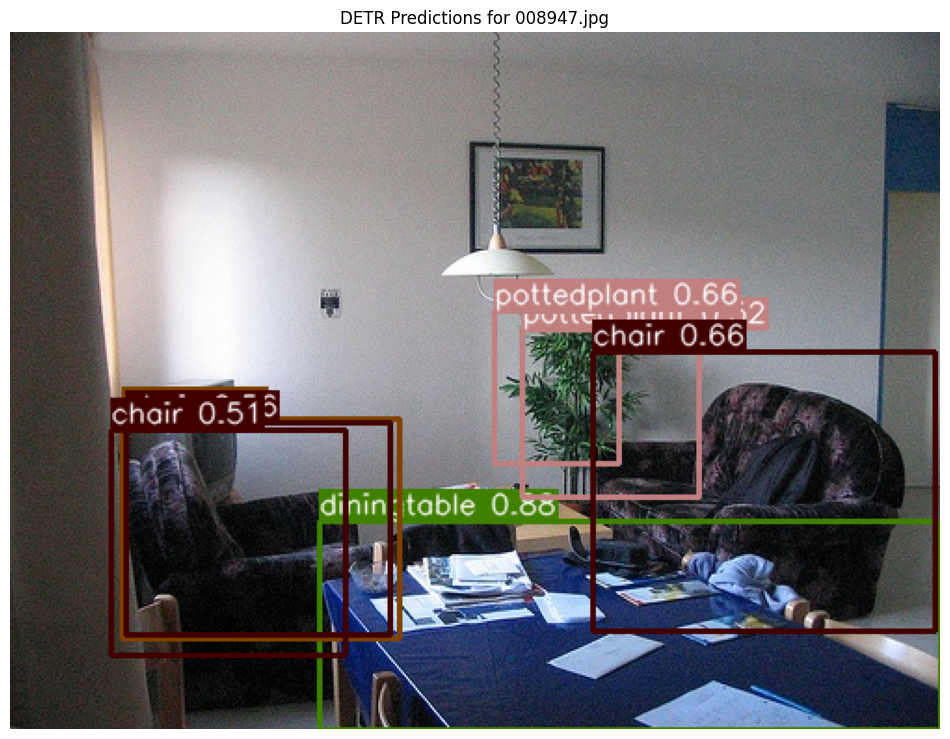

```python
from src.predict import predict_image_detr


def load_checkpoint_for_inference(checkpoint_path: Path):
    inference_model = SimpleDETR(
        num_classes=len(VOC_CLASSES),
        backbone=backbone,
        num_queries=num_queries,
        d_model=d_model,
        nhead=nhead,
        num_encoder_layers=num_encoder_layers,
        num_decoder_layers=num_decoder_layers,
        dim_feedforward=dim_feedforward,
        dropout=dropout,
    ).to(device)
    inference_model.load_state_dict(torch.load(checkpoint_path, map_location=device))
    inference_model.eval()
    return inference_model


checkpoint_path = Path("runs/detr_5e-06/detector_last.pth")

inference_model = load_checkpoint_for_inference(checkpoint_path)
image_name = random.choice(test_dataset.fnames)
image_bgr = cv2.imread(str(file_root_test / image_name))
image_rgb = cv2.cvtColor(image_bgr, cv2.COLOR_BGR2RGB)

# Play around with the confidence threshold to see how they affect the predictions.
detections = predict_image_detr(
    model=inference_model,
    image_name=image_name,
    root_img_directory=str(file_root_test),
    conf_threshold = 0.5,
)

canvas = image_rgb.copy()
for det in detections:
    class_idx = VOC_CLASSES.index(det.class_name)
    color = tuple(int(c) for c in COLORS[class_idx])
    x1, y1, x2, y2 = det.box.astype(int).tolist()
    cv2.rectangle(canvas, (x1, y1), (x2, y2), color, 2)
    label = f"{det.class_name} {det.score:.2f}"
    (w, h), baseline = cv2.getTextSize(label, cv2.FONT_HERSHEY_SIMPLEX, 0.5, 1)
    text_x = x1
    text_y = max(h + 5, y1)
    cv2.rectangle(
        canvas,
        (text_x, text_y - h - baseline),
        (text_x + w, text_y),
        color,
        thickness=-1,
    )
    cv2.putText(
        canvas,
        label,
        (x1, max(15, y1 - 4)),
        cv2.FONT_HERSHEY_SIMPLEX,
        0.5,
        (255, 255, 255),
        1,
        cv2.LINE_AA,
    )

plt.figure(figsize=(12, 12))
plt.imshow(canvas)
plt.title(f"DETR Predictions for {image_name}")
plt.axis("off")
plt.show()
```

## Evaluate on Test

To evaluate detection results we use mAP (mean of average precision over each class).

```python
checkpoint_path = Path("runs/detr/detector_last.pth")
eval_model = load_checkpoint_for_inference(checkpoint_path)
eval_results = evaluate_detr(eval_model, print_results=True, **eval_kwargs)

print(f"\nFinal mAP: {eval_results['map']:.4f}")
```

[output not shown]

## Export Submission CSV

```python
def write_submission_csv(output_path, eval_results):
    output_path = Path(output_path)
    with output_path.open("w", newline="") as handle:
        writer = csv.writer(handle)
        writer.writerow(["id", "expected"])
        for idx, ap in enumerate(eval_results["aps"]):
            writer.writerow([idx, float(ap)])
    return output_path.resolve()


submission_path = write_submission_csv("my_solution_detr.csv", eval_results)
print(f"Wrote submission file to: {submission_path}")
```

```
Wrote submission file to: /u/akoric/myproject/assignment4_starter_sp26/my_solution_detr.csv
```

# Extra Credit

### Smooth L1 Loss

Experiment with alternative losses: Smooth L1 loss, Focal loss, advanced IoU losses (e.g., Distance IoU, Complete IoU), etc. Compare performance to the YOLO and DETR losses.

Replace the L1 bounding-box regression term with Smooth L1 loss. Trained with backbone_lr = 1e-5 and the same head hyperparameters as the main model.

```python
backbone_learning_rate = 1e-5

load_network_path = None

model = SimpleDETR(
    num_classes=len(VOC_CLASSES),
    backbone=backbone,
    num_queries=num_queries,
    d_model=d_model,
    nhead=nhead,
    num_encoder_layers=num_encoder_layers,
    num_decoder_layers=num_decoder_layers,
    dim_feedforward=dim_feedforward,
    dropout=dropout,
).to(device)

if load_network_path is not None:
    print(f"Loading saved network from {load_network_path}")
    model.load_state_dict(torch.load(load_network_path, map_location=device))
else:
    print(f"Initialized SimpleDETR with backbone: {backbone}")

print(f"Parameter count: {count_parameters(model) / 1e6:.2f}M")

reload(detr_loss_module)
matcher = detr_loss_module.HungarianMatcher(
    cost_class=1.0, cost_bbox=5.0, cost_giou=2.0
)
weight_dict = {"loss_ce": 1.0, "loss_bbox": 5.0, "loss_giou": 2.0}

eos_coef = 0.2
criterion = detr_loss_module.DETRSetCriterion(
    num_classes=len(VOC_CLASSES),
    matcher=matcher,
    weight_dict=weight_dict,
    eos_coef=eos_coef,
    use_smooth_l1=True,
).to(device)

backbone_params = []
head_params = []
for name, param in model.named_parameters():
    if not param.requires_grad:
        continue
    if name.startswith("backbone."):
        backbone_params.append(param)
    else:
        head_params.append(param)

print(f"Backbone learning rate: {backbone_learning_rate:.4g}")
print(f"Head learning rate:     {head_learning_rate:.4g}")

optimizer = torch.optim.AdamW(
    [
        {"params": head_params, "lr": head_learning_rate},
        {"params": backbone_params, "lr": backbone_learning_rate},
    ],
    weight_decay=1e-4,
)
scheduler = torch.optim.lr_scheduler.CosineAnnealingLR(
    optimizer,
    T_max=num_epochs,
    eta_min=0.0,
)

lr_ratio = backbone_learning_rate / head_learning_rate
```

```
Initialized SimpleDETR with backbone: facebook/dinov2-with-registers-small
Parameter count: 28.35M
Backbone learning rate: 1e-05
Head learning rate:     0.00015
```

```python
from collections import defaultdict
from tqdm import tqdm

from src.eval import evaluate_detr

seed_everything(SEED)


@torch.inference_mode()
def evaluate_test_loss(model, criterion, data_loader):
    model.eval()
    criterion.eval()
    loss_sums = defaultdict(float)
    num_batches = 0

    for images, targets in data_loader:
        images = [img.to(device, non_blocking=True) for img in images]
        targets = [
            {
                k: (v.to(device, non_blocking=True) if torch.is_tensor(v) else v)
                for k, v in t.items()
            }
            for t in targets
        ]

        outputs = model(images)
        loss_dict = criterion(outputs, targets)
        total_loss = compute_total_loss(loss_dict, weight_dict)
        loss_sums["total_loss"] += float(total_loss.item())
        for key, value in loss_dict.items():
            loss_sums[key] += float(value.item())
        num_batches += 1

    return {key: value / max(num_batches, 1) for key, value in loss_sums.items()}


print_per_class_mAP = False

final_map = 0.0
final_test_loss = 0.0

global_step = 0

run_dir = Path("runs/detr_smooth_l1")
run_dir.mkdir(parents=True, exist_ok=True)

warmup_epochs = 0.5
steps_per_epoch = len(train_loader)
warmup_steps = max(0, int(round(warmup_epochs * steps_per_epoch)))

start_time = time.time()
epoch_pbar = tqdm(range(num_epochs), desc="Training")

freeze_backbone_epochs = 2.0

for epoch in epoch_pbar:
    model.train()
    criterion.train()
    train_sums = defaultdict(float)

    # Freeze backbone for the first freeze_backbone_epochs epochs
    backbone_mult = 0.0 if float(epoch) < freeze_backbone_epochs else 1.0
    epoch_head_lr = float(optimizer.param_groups[0]["lr"])
    epoch_backbone_lr = epoch_head_lr * lr_ratio * backbone_mult
    optimizer.param_groups[1]["lr"] = epoch_backbone_lr

    for step, (images, targets) in enumerate(train_loader, start=1):
        global_step += 1

        # Linear warmup during the first warmup_steps steps
        if warmup_steps > 0 and global_step <= warmup_steps:
            w = float(global_step) / float(warmup_steps)
            optimizer.param_groups[0]["lr"] = epoch_head_lr * w
            optimizer.param_groups[1]["lr"] = epoch_backbone_lr * w
        else:
            optimizer.param_groups[0]["lr"] = epoch_head_lr
            optimizer.param_groups[1]["lr"] = epoch_backbone_lr

        images = [img.to(device, non_blocking=True) for img in images]
        targets = [
            {
                k: (v.to(device, non_blocking=True) if torch.is_tensor(v) else v)
                for k, v in t.items()
            }
            for t in targets
        ]

        outputs = model(images)
        loss_dict = criterion(outputs, targets)
        total_loss = compute_total_loss(loss_dict, weight_dict)

        optimizer.zero_grad(set_to_none=True)
        total_loss.backward()
        torch.nn.utils.clip_grad_norm_(model.parameters(), 0.1)
        optimizer.step()

        train_sums["total_loss"] += float(total_loss.item())
        for key, value in loss_dict.items():
            train_sums[key] += float(value.item())

        if step % max(1, len(train_loader) // 10) == 0 or step == len(train_loader):
            epoch_pbar.set_postfix(
                epoch=epoch + 1,
                iter=f"{step}/{len(train_loader)}",
                lr=f'{optimizer.param_groups[0]["lr"]:.2e}',
                total=f'{train_sums["total_loss"] / step:.3f}',
                ce=f'{train_sums["loss_ce"] / step:.3f}',
                bbox=f'{train_sums["loss_bbox"] / step:.3f}',
            )

    if (epoch + 1) % eval_every == 0:
        eval_results = evaluate_detr(model, print_results=False, **eval_kwargs)
        eval_loss_dict = evaluate_test_loss(model, criterion, test_loader)
        epoch_map = float(eval_results["map"])
        epoch_test_loss = float(eval_loss_dict["total_loss"])
        final_map = epoch_map
        final_test_loss = epoch_test_loss
        tqdm.write(
            f"Epoch {epoch + 1}: test_mAP={epoch_map:.4f}, test_loss={epoch_test_loss:.4f}"
        )

    if (epoch + 1) % save_every == 0:
        torch.save(model.state_dict(), run_dir / f"detector_epoch_{epoch + 1}.pth")
    torch.save(model.state_dict(), run_dir / "detector_last.pth")

    scheduler.step()

    epoch_pbar.set_postfix(
        epoch=epoch + 1,
        total=f'{train_sums["total_loss"] / len(train_loader):.3f}',
        ce=f'{train_sums["loss_ce"] / len(train_loader):.3f}',
        bbox=f'{train_sums["loss_bbox"] / len(train_loader):.3f}',
    )

training_seconds = time.time() - start_time
print(f"Finished training in {training_seconds:.1f}s")
print(f"Final test mAP: {final_map:.4f}")
print(f"Final test loss: {final_test_loss:.4f}")
```

```
  output = torch._nested_tensor_from_mask(
```

```
Epoch 1: test_mAP=0.2113, test_loss=4.9574
```

```
Epoch 2: test_mAP=0.1583, test_loss=4.5534
```

```
Epoch 3: test_mAP=0.2025, test_loss=4.5493
```

```
Epoch 4: test_mAP=0.2222, test_loss=4.5707
```

```
Epoch 5: test_mAP=0.2022, test_loss=4.3799
```

```
Epoch 6: test_mAP=0.2563, test_loss=4.0221
```

```
Epoch 7: test_mAP=0.2862, test_loss=3.6811
```

```
Epoch 8: test_mAP=0.3282, test_loss=3.5412
```

```
Epoch 9: test_mAP=0.3688, test_loss=3.5582
```

```
Epoch 10: test_mAP=0.4230, test_loss=3.3473
```

```
Epoch 11: test_mAP=0.4501, test_loss=3.1734
```

```
Epoch 12: test_mAP=0.4702, test_loss=3.1208
```

```
Epoch 13: test_mAP=0.5015, test_loss=3.0219
```

```
Epoch 14: test_mAP=0.5163, test_loss=2.9966
```

```
Epoch 15: test_mAP=0.5250, test_loss=2.9637
Finished training in 2607.0s
Final test mAP: 0.5250
Final test loss: 2.9637
```

```python
from src.predict import predict_image_detr


def load_checkpoint_for_inference(checkpoint_path: Path):
    inference_model = SimpleDETR(
        num_classes=len(VOC_CLASSES),
        backbone=backbone,
        num_queries=num_queries,
        d_model=d_model,
        nhead=nhead,
        num_encoder_layers=num_encoder_layers,
        num_decoder_layers=num_decoder_layers,
        dim_feedforward=dim_feedforward,
        dropout=dropout,
    ).to(device)
    inference_model.load_state_dict(torch.load(checkpoint_path, map_location=device))
    inference_model.eval()
    return inference_model


checkpoint_path = Path("runs/detr_smooth_l1/detector_last.pth")

eval_model = load_checkpoint_for_inference(checkpoint_path)
eval_results = evaluate_detr(eval_model, print_results=True, **eval_kwargs)

print(f"\nFinal mAP: {eval_results['map']:.4f}")
```

```
Evaluating on 4950 images...

VOC Evaluation Results
===============================================================================
Class                      AP       Prec     Recall      #Pred        #GT
-------------------------------------------------------------------------------
aeroplane              0.4938     0.1806     0.7053       1113        285
bicycle                0.6898     0.3730     0.8101        732        337
bird                   0.3985     0.1817     0.6667       1684        459
boat                   0.3923     0.1668     0.6616       1043        263
bottle                 0.1330     0.1641     0.3156        902        469
bus                    0.7479     0.3285     0.8498        551        213
car                    0.5528     0.2589     0.7167       3322       1200
cat                    0.8179     0.2858     0.9358       1172        358
chair                  0.3115     0.1905     0.6194       2451        754
cow                    0.4597     0.2373     0.7090        729        244
diningtable            0.7021     0.2770     0.8350        621        206
dog                    0.7228     0.3007     0.8855       1440        489
horse                  0.7674     0.3046     0.8621        985        348
motorbike              0.6166     0.2788     0.7815        911        325
person                 0.3836     0.2681     0.6650      11231       4528
pottedplant            0.1643     0.1352     0.3896       1383        480
sheep                  0.3554     0.2185     0.6446        714        242
sofa                   0.6245     0.1852     0.9076       1166        238
train                  0.7260     0.2177     0.8794       1139        282
tvmonitor              0.4401     0.2413     0.6786        866        308
-------------------------------------------------------------------------------
mAP                    0.5250
===============================================================================

Final mAP: 0.5250
```

### ResNet34 Backbone

Experiment with other ResNet variants for YOLO and/or DETR for more direct comparisons between different model settings (e.g., YOLO+ResNet18 vs. YOLO+ResNet34 vs. DETR+ResNet34 vs. DETR+DINOv2 -- ResNet34 and DINOv2-small have similar parameter counts).

Replace the ViT backbone with a ResNet34 CNN backbone.

```python
backbone_resnet34 = "resnet34"
backbone_learning_rate = 1e-5

resnet34_train_dataset = VOCDetectionDataset(
    root_img_dir=file_root_train,
    dataset_file=annotation_file_train,
    train=True,
    detector_type="detr",
    backbone=backbone_resnet34,
    image_size=IMG_MAX_SIZE,
    augmentation=True,
)
resnet34_test_dataset = VOCDetectionDataset(
    root_img_dir=file_root_test,
    dataset_file=annotation_file_test,
    train=False,
    detector_type="detr",
    backbone=backbone_resnet34,
    image_size=IMG_MAX_SIZE,
    augmentation=False,
)

resnet34_train_loader = data.DataLoader(
    resnet34_train_dataset,
    batch_size=batch_size,
    shuffle=True,
    num_workers=2,
    pin_memory=torch.cuda.is_available(),
    persistent_workers=True,
    collate_fn=collate_fn_detr,
)
resnet34_test_loader = data.DataLoader(
    resnet34_test_dataset,
    batch_size=batch_size,
    shuffle=False,
    num_workers=2,
    pin_memory=torch.cuda.is_available(),
    persistent_workers=True,
    collate_fn=collate_fn_detr,
)

print(f"Loaded {len(resnet34_train_dataset)} training images")
print(f"Loaded {len(resnet34_test_dataset)} test images")

load_network_path = None

model = SimpleDETR(
    num_classes=len(VOC_CLASSES),
    backbone=backbone_resnet34,
    num_queries=num_queries,
    d_model=d_model,
    nhead=nhead,
    num_encoder_layers=num_encoder_layers,
    num_decoder_layers=num_decoder_layers,
    dim_feedforward=dim_feedforward,
    dropout=dropout,
).to(device)

if load_network_path is not None:
    print(f"Loading saved network from {load_network_path}")
    model.load_state_dict(torch.load(load_network_path, map_location=device))
else:
    print(f"Initialized SimpleDETR with backbone: {backbone_resnet34}")

print(f"Parameter count: {count_parameters(model) / 1e6:.2f}M")

reload(detr_loss_module)
matcher = detr_loss_module.HungarianMatcher(
    cost_class=1.0, cost_bbox=5.0, cost_giou=2.0
)
weight_dict = {"loss_ce": 1.0, "loss_bbox": 5.0, "loss_giou": 2.0}

eos_coef = 0.2
criterion = detr_loss_module.DETRSetCriterion(
    num_classes=len(VOC_CLASSES),
    matcher=matcher,
    weight_dict=weight_dict,
    eos_coef=eos_coef,
).to(device)

backbone_params = []
head_params = []
for name, param in model.named_parameters():
    if not param.requires_grad:
        continue
    if name.startswith("backbone."):
        backbone_params.append(param)
    else:
        head_params.append(param)

print(f"Backbone learning rate: {backbone_learning_rate:.4g}")
print(f"Head learning rate:     {head_learning_rate:.4g}")

optimizer = torch.optim.AdamW(
    [
        {"params": head_params, "lr": head_learning_rate},
        {"params": backbone_params, "lr": backbone_learning_rate},
    ],
    weight_decay=1e-4,
)
scheduler = torch.optim.lr_scheduler.CosineAnnealingLR(
    optimizer,
    T_max=num_epochs,
    eta_min=0.0,
)

lr_ratio = backbone_learning_rate / head_learning_rate
```

```
Loaded 5011 training images
Loaded 4950 test images
Initialized SimpleDETR with backbone: resnet34
Parameter count: 27.61M
Backbone learning rate: 1e-05
Head learning rate:     0.00015
```

```python
from collections import defaultdict
from tqdm import tqdm

from src.eval import evaluate_detr

seed_everything(SEED)


@torch.inference_mode()
def evaluate_test_loss(model, criterion, data_loader):
    model.eval()
    criterion.eval()
    loss_sums = defaultdict(float)
    num_batches = 0

    for images, targets in data_loader:
        images = [img.to(device, non_blocking=True) for img in images]
        targets = [
            {
                k: (v.to(device, non_blocking=True) if torch.is_tensor(v) else v)
                for k, v in t.items()
            }
            for t in targets
        ]

        outputs = model(images)
        loss_dict = criterion(outputs, targets)
        total_loss = compute_total_loss(loss_dict, weight_dict)
        loss_sums["total_loss"] += float(total_loss.item())
        for key, value in loss_dict.items():
            loss_sums[key] += float(value.item())
        num_batches += 1

    return {key: value / max(num_batches, 1) for key, value in loss_sums.items()}


print_per_class_mAP = False

final_map = 0.0
final_test_loss = 0.0

global_step = 0

run_dir = Path("runs/detr_resnet34")
run_dir.mkdir(parents=True, exist_ok=True)

warmup_epochs = 0.5
steps_per_epoch = len(resnet34_train_loader)
warmup_steps = max(0, int(round(warmup_epochs * steps_per_epoch)))

start_time = time.time()
epoch_pbar = tqdm(range(num_epochs), desc="Training")

freeze_backbone_epochs = 2.0

for epoch in epoch_pbar:
    model.train()
    criterion.train()
    train_sums = defaultdict(float)

    # Freeze backbone for the first freeze_backbone_epochs epochs
    backbone_mult = 0.0 if float(epoch) < freeze_backbone_epochs else 1.0
    epoch_head_lr = float(optimizer.param_groups[0]["lr"])
    epoch_backbone_lr = epoch_head_lr * lr_ratio * backbone_mult
    optimizer.param_groups[1]["lr"] = epoch_backbone_lr

    for step, (images, targets) in enumerate(resnet34_train_loader, start=1):
        global_step += 1

        # Linear warmup during the first warmup_steps steps
        if warmup_steps > 0 and global_step <= warmup_steps:
            w = float(global_step) / float(warmup_steps)
            optimizer.param_groups[0]["lr"] = epoch_head_lr * w
            optimizer.param_groups[1]["lr"] = epoch_backbone_lr * w
        else:
            optimizer.param_groups[0]["lr"] = epoch_head_lr
            optimizer.param_groups[1]["lr"] = epoch_backbone_lr

        images = [img.to(device, non_blocking=True) for img in images]
        targets = [
            {
                k: (v.to(device, non_blocking=True) if torch.is_tensor(v) else v)
                for k, v in t.items()
            }
            for t in targets
        ]

        outputs = model(images)
        loss_dict = criterion(outputs, targets)
        total_loss = compute_total_loss(loss_dict, weight_dict)

        optimizer.zero_grad(set_to_none=True)
        total_loss.backward()
        torch.nn.utils.clip_grad_norm_(model.parameters(), 0.1)
        optimizer.step()

        train_sums["total_loss"] += float(total_loss.item())
        for key, value in loss_dict.items():
            train_sums[key] += float(value.item())

        if step % max(1, len(resnet34_train_loader) // 10) == 0 or step == len(resnet34_train_loader):
            epoch_pbar.set_postfix(
                epoch=epoch + 1,
                iter=f"{step}/{len(resnet34_train_loader)}",
                lr=f'{optimizer.param_groups[0]["lr"]:.2e}',
                total=f'{train_sums["total_loss"] / step:.3f}',
                ce=f'{train_sums["loss_ce"] / step:.3f}',
                bbox=f'{train_sums["loss_bbox"] / step:.3f}',
            )

    if (epoch + 1) % eval_every == 0:
        eval_results = evaluate_detr(model, print_results=False, **eval_kwargs)
        eval_loss_dict = evaluate_test_loss(model, criterion, resnet34_test_loader)
        epoch_map = float(eval_results["map"])
        epoch_test_loss = float(eval_loss_dict["total_loss"])
        final_map = epoch_map
        final_test_loss = epoch_test_loss
        tqdm.write(
            f"Epoch {epoch + 1}: test_mAP={epoch_map:.4f}, test_loss={epoch_test_loss:.4f}"
        )

    if (epoch + 1) % save_every == 0:
        torch.save(model.state_dict(), run_dir / f"detector_epoch_{epoch + 1}.pth")
    torch.save(model.state_dict(), run_dir / "detector_last.pth")

    scheduler.step()

    epoch_pbar.set_postfix(
        epoch=epoch + 1,
        total=f'{train_sums["total_loss"] / len(resnet34_train_loader):.3f}',
        ce=f'{train_sums["loss_ce"] / len(resnet34_train_loader):.3f}',
        bbox=f'{train_sums["loss_bbox"] / len(resnet34_train_loader):.3f}',
    )

training_seconds = time.time() - start_time
print(f"Finished training in {training_seconds:.1f}s")
print(f"Final test mAP: {final_map:.4f}")
print(f"Final test loss: {final_test_loss:.4f}")
```

```
  output = torch._nested_tensor_from_mask(
```

```
Epoch 1: test_mAP=0.0989, test_loss=7.9839
```

```
Epoch 2: test_mAP=0.1400, test_loss=7.3178
```

```
Epoch 3: test_mAP=0.1546, test_loss=7.0054
```

```
Epoch 4: test_mAP=0.2011, test_loss=6.4259
```

```
Epoch 5: test_mAP=0.2075, test_loss=6.4478
```

```
Epoch 6: test_mAP=0.2163, test_loss=6.0487
```

```
Epoch 7: test_mAP=0.2129, test_loss=5.7876
```

```
Epoch 8: test_mAP=0.2628, test_loss=5.5209
```

```
Epoch 9: test_mAP=0.2479, test_loss=5.4660
```

```
Epoch 10: test_mAP=0.2608, test_loss=5.3115
```

```
Epoch 11: test_mAP=0.3067, test_loss=5.0854
```

```
Epoch 12: test_mAP=0.3228, test_loss=4.9141
```

```
Epoch 13: test_mAP=0.3304, test_loss=4.8161
```

```
Epoch 14: test_mAP=0.3361, test_loss=4.8179
```

```
Epoch 15: test_mAP=0.3443, test_loss=4.8243
Finished training in 2070.7s
Final test mAP: 0.3443
Final test loss: 4.8243
```

```python
from src.eval import evaluate_detr

def load_checkpoint_for_inference_rn34(checkpoint_path: Path):
    inference_model = SimpleDETR(
        num_classes=len(VOC_CLASSES),
        backbone="resnet34",
        num_queries=num_queries,
        d_model=d_model,
        nhead=nhead,
        num_encoder_layers=num_encoder_layers,
        num_decoder_layers=num_decoder_layers,
        dim_feedforward=dim_feedforward,
        dropout=dropout,
    ).to(device)
    inference_model.load_state_dict(torch.load(checkpoint_path, map_location=device))
    inference_model.eval()
    return inference_model


checkpoint_path = Path("runs/detr_resnet34/detector_last.pth")

eval_model = load_checkpoint_for_inference_rn34(checkpoint_path)
eval_results = evaluate_detr(eval_model, print_results=True, **eval_kwargs)

print(f"\nFinal mAP: {eval_results['map']:.4f}")
```

```
Evaluating on 4950 images...
```

```
VOC Evaluation Results
===============================================================================
Class                      AP       Prec     Recall      #Pred        #GT
-------------------------------------------------------------------------------
aeroplane              0.4525     0.1041     0.5825       1594        285
bicycle                0.4432     0.2007     0.6736       1131        337
bird                   0.2484     0.1128     0.5817       2366        459
boat                   0.2125     0.0719     0.4563       1669        263
bottle                 0.0665     0.0799     0.2239       1314        469
bus                    0.5230     0.1818     0.6385        748        213
car                    0.4455     0.1327     0.5917       5349       1200
cat                    0.5250     0.1392     0.8547       2198        358
chair                  0.1281     0.0978     0.3979       3068        754
cow                    0.2083     0.0940     0.4508       1170        244
diningtable            0.5501     0.2640     0.6650        519        206
dog                    0.4331     0.1370     0.7996       2853        489
horse                  0.5723     0.2009     0.7385       1279        348
motorbike              0.4071     0.1925     0.6308       1065        325
person                 0.2237     0.1734     0.5201      13584       4528
pottedplant            0.0600     0.0567     0.2333       1976        480
sheep                  0.1478     0.0960     0.3926        990        242
sofa                   0.4501     0.1196     0.7227       1438        238
train                  0.5789     0.1356     0.7199       1497        282
tvmonitor              0.2161     0.0954     0.5032       1624        308
-------------------------------------------------------------------------------
mAP                    0.3446
===============================================================================

Final mAP: 0.3446
```